# Week 5 - Assumptions

Flora Le (flora.le@monash.edu)

2023-08-20

# 1 Intro

This week we focus on checking and dealing with parametric assumptions for linear regression and ANOVA and explore a very cool package `ggplot2` in R for data visualisation.

# 2 Packages

First thing first. Open your R project and load the packages.

```r
library(data.table)
library(psych)
library(car)
library(ggplot2)
library(JWileymisc)
library(extraoperators)
```

# 3 Data

Let’s start by loading your dataset for the research report - *PSY3062 dataset.csv*.

```r
d <- fread("/Users/florale/Library/CloudStorage/OneDrive-MonashUniversity/Work/MonashTA/PSY3062_2022/PSY3062 dataset.csv")
```

# 4 Scoring practice

**Exercise**

Score at least 2 continuous variables you have chosen for your research report.

**Notes** I have scored 2 random variables in the dataset *in secret* 👩🏻‍💻, called `Variable1` and `Variable2`. We will use them to check assumptions. You should score your own variables and replace `Variable1` and `Variable2` with them to run the code.

```r
# secret scoring script
source("secure_scoring.R")
```

# 5 Intro to `ggplot2`

Visualising data is an efficient way to understand our data and communicate our work. There are several packages in `R` for producing statistical, or data, graphics. This week we focus on inspecting/visualising our data and check assumptions using several functions from base R or a very cool package `ggplot2`.

ggplot is based on **G**rammar of **G**raphics. ggplot is very powerful in a way that we can build and customise our graphics. We can do this by building layer by layer by adding “geom” elements. This workshop only covers the basics of `ggplot2`. Let’s start with `ggplot2` formula.

The base formula to build ggplot is `ggplot(data, mapping) + geoms()`.

- `ggplot()` builds base plot.
- `data` binds the plot to a specific dataset.
- `mapping` uses the aesthetic `aes()` function to select variables to be plotted and specify how to present them in the graph, e.g., as x/y positions or characteristics such as size, shape, color, etc.
- `geoms()` adds geoms to specify how to represent the data in the plot (points, lines, bars).

Common geoms, some of which we will be using today:

- `geom_point()` scatter plots, dot plots, etc.
- `geom_line()` trend lines, etc.
- `geom_boxplot()` boxplots.
- `geom_smooth()` to check patterns in your data (e.g., linearity).
- `geom_histogram()` and `geom_density()` to check distribution.

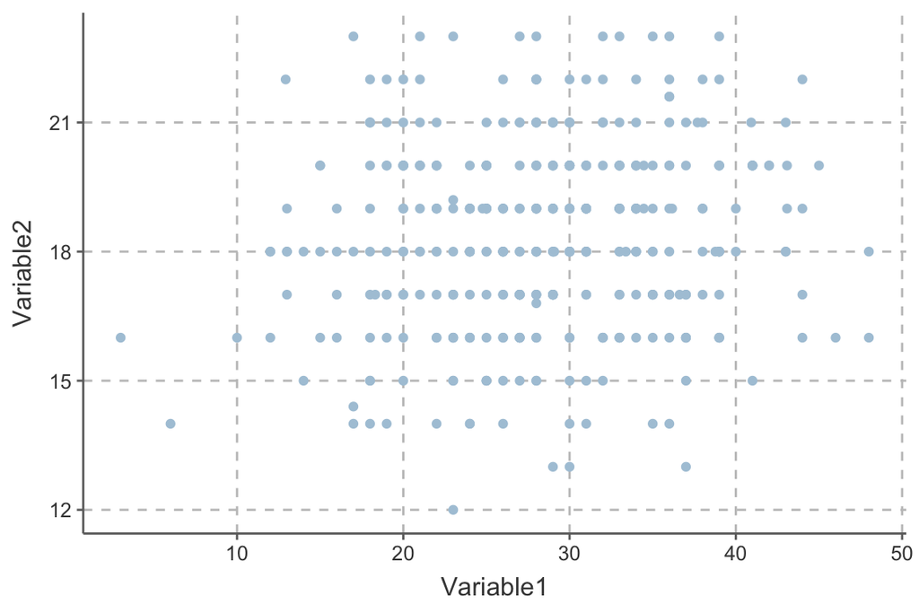

```r
# example scatter plot
ggplot(d,
       aes(
         x = Variable1,
         y = Variable2)) +
  geom_point()
```

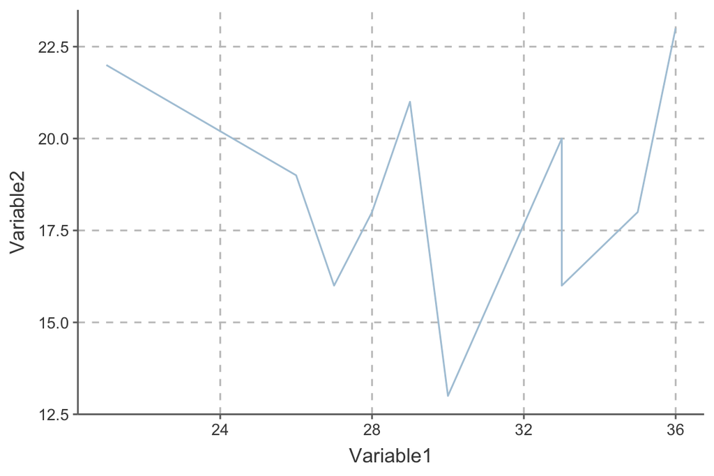

```r
# example line plot
ggplot(d[1:10, ],
       aes(
         x = Variable1,
         y = Variable2)) +
  geom_line()
```

# 6 Assumptions

We often use graphs to visually assess assumptions, such as normality and for outliers. There are several ways to check assumptions in `R`. You can choose from Base R or `ggplot2`. It’s up to you which functions you use, they will probably ultimately give you the same results. Let’s apply ggplot principles to inspect our data and check assumptions.

## 6.1 Linearity

### 6.1.1 Scatter Plot

Scatter Plot is probably the easiest way to check linearity.

**Code Template for Scatter Plot**

- For Base R, use `plot()` function: `plot(dataset_name$iv_name, dataset_name$dv_name)`
- For ggplot, use `geom_point()` function

```r
# base R plot
plot(d$Variable1, d$Variable2)
```

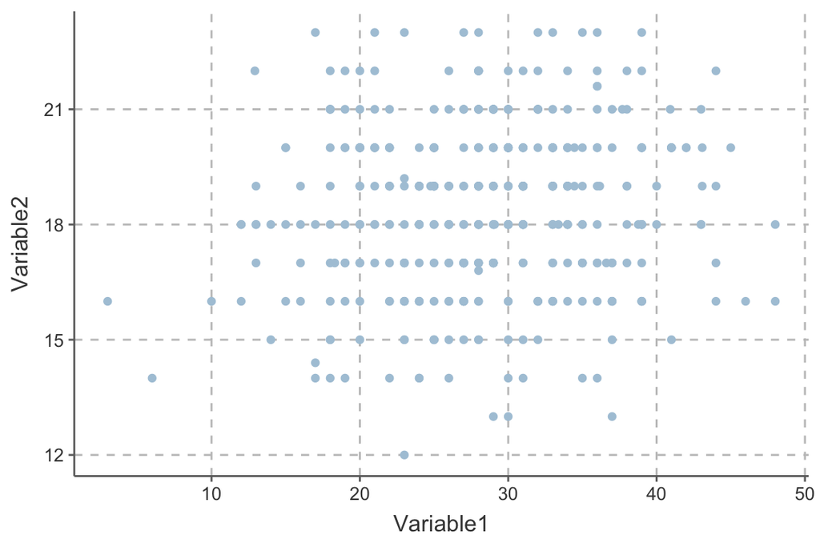

```r
# ggplot
ggplot(d,
       aes(
         x = Variable1,
         y = Variable2)) +
  geom_point()
```

### 6.1.2 Adding a line to Scatter Plot

We can add a line to the plot to visualise the data/relationship easily by using the `geom_smooth()` function.

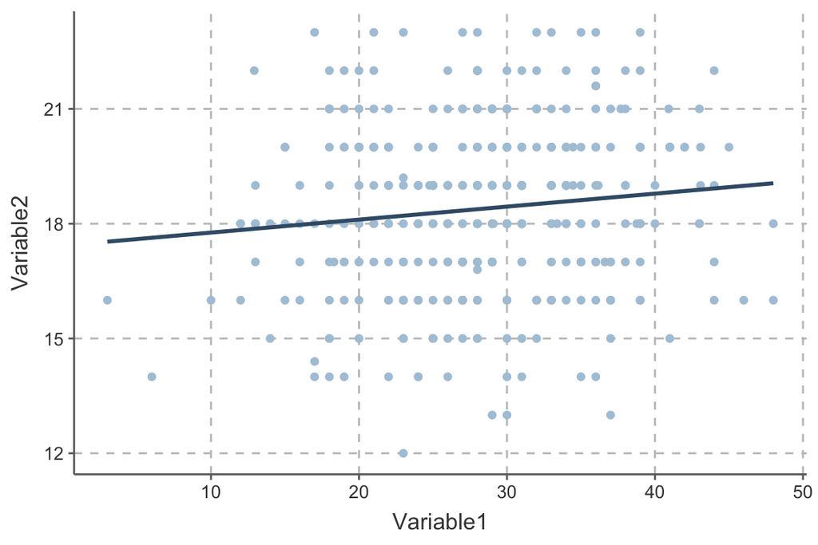

```r
ggplot(d,
       aes(
         x = Variable1,
         y = Variable2)) +
  geom_point() +
  geom_smooth(method = 'lm', se = FALSE)
```

**You Try It**

Check **Linearity** assumption using 2 variables that you just scored. Does their relationship follow a straight line?

## 6.2 Normality

### 6.2.1 Shapiro-Wilk test

**Code Template for Shapiro-Wilk test**

`shapiro.test(dataset_name$variable_name)`

```r
shapiro.test(d$Variable1)
```

```
##
##  Shapiro-Wilk normality test
##
## data:  d$Variable1
## W = 1, p-value = 0.5
```

### 6.2.2 Histogram

**Code Template for Histogram**

- For Base R, use `hist()` function: `hist(dataset_name$variable_name)`
- For ggplot, use `geom_histogram()` or `geom_density()`

```r
# base R
hist(d$Variable1)
```

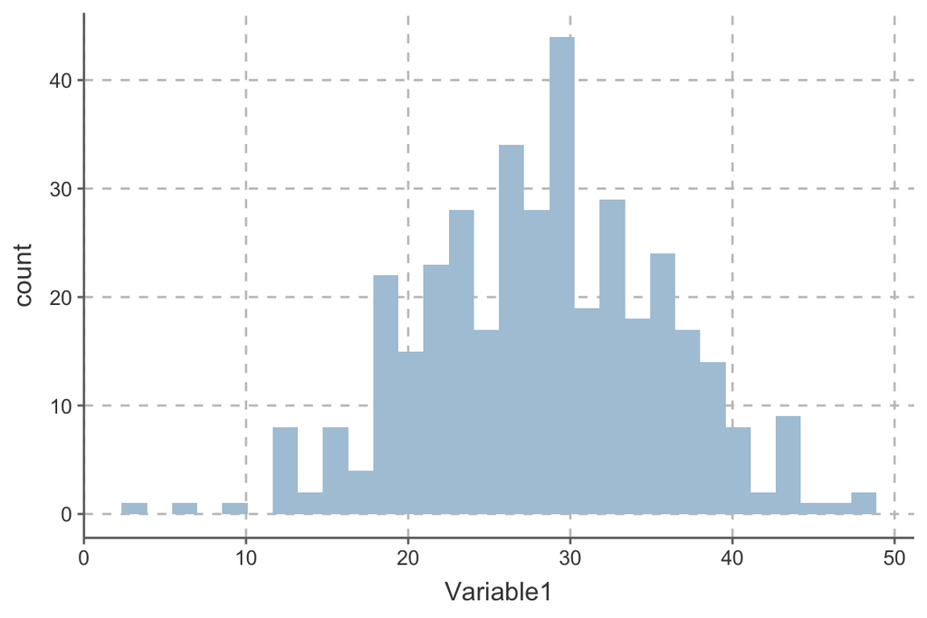

```r
# ggplot
ggplot(d,
       aes(x = Variable1)) +
  geom_histogram()
```

We can also use a density plot using the `geom_density()` function, which also attempts to show the distribution, but using a smooth density function rather than binning the data and plotting the frequencies like how the `geom_histogram()` does.

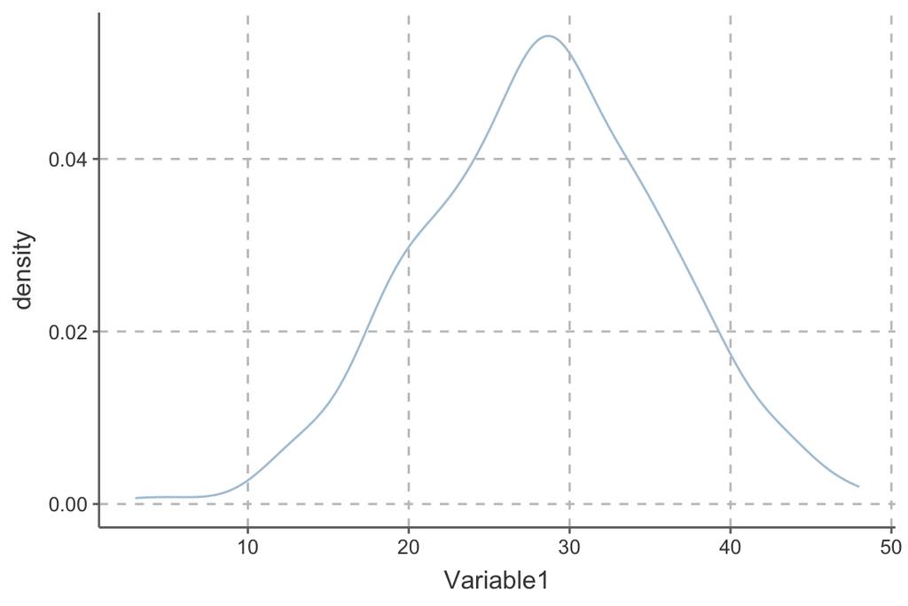

```r
ggplot(d,
       aes(x = Variable1)) +
  geom_density()
```

### 6.2.3 QQ Plot

**Code Template for QQ Plot**

`qplot(sample = variable_name, data = dataset_name)`

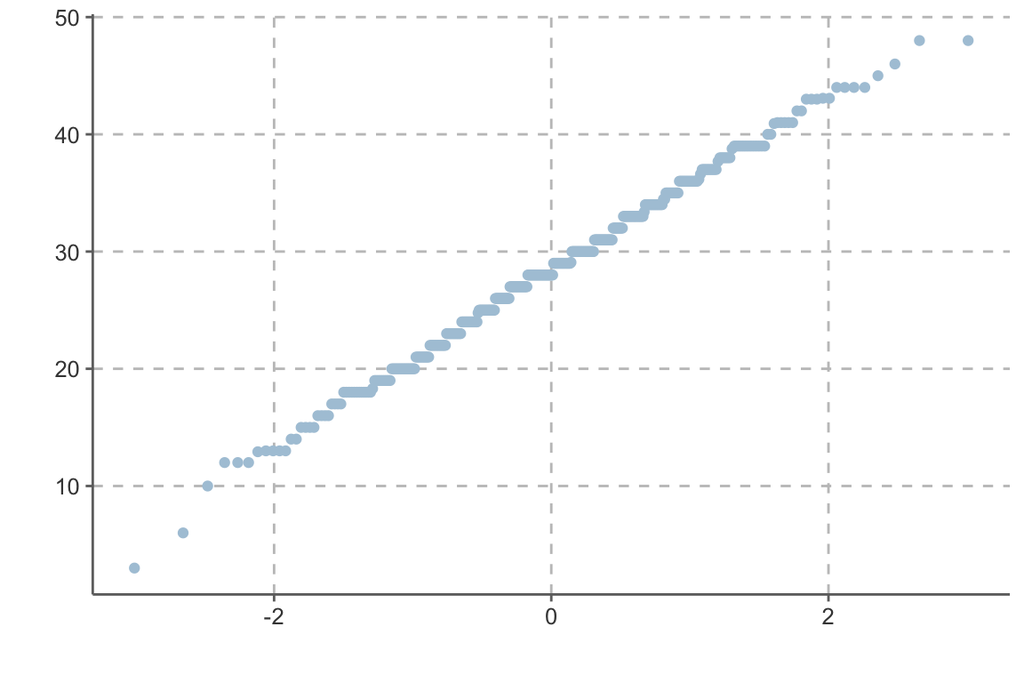

```r
qplot(sample = Variable1, data = d)
```

**You Try It**

Check **Normality** assumption for one or more variables that you just scored. Do your variables follow normal distributions?

### 6.2.4 Box plots

Boxplots can be used to visualize the distribution of variables and extreme values.

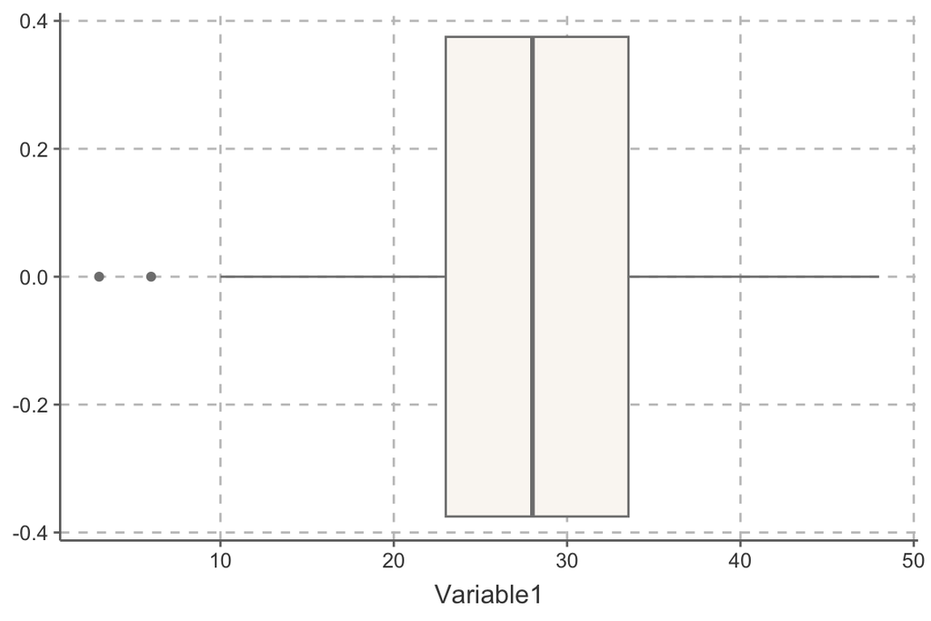

```r
# ggplot
ggplot(d,
       aes(
         x = Variable1)) +
  geom_boxplot(color = "#7F7F7F", fill = "#FAF7F3")
```

### 6.2.5 Box plot by groups

We can also use boxplot to check distribution of variables in different groups. Here I compare the distribution of Variable 1 between males and females.

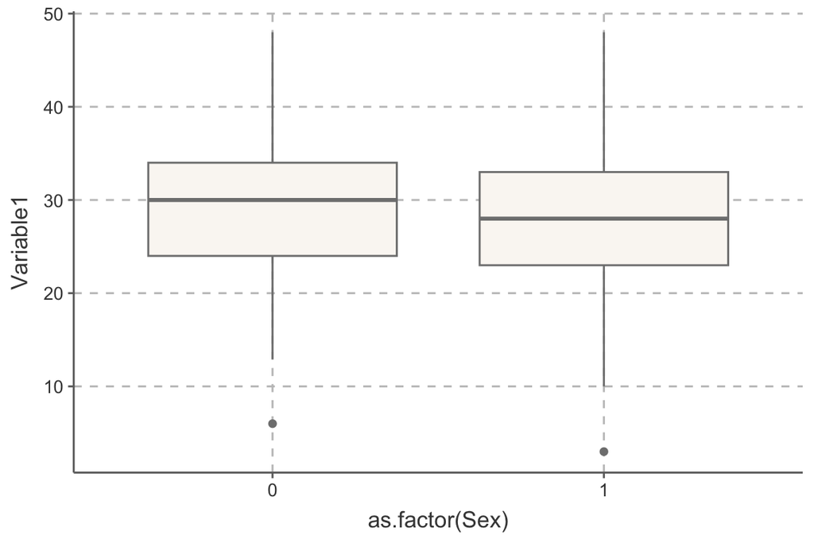

```r
ggplot(d,
       aes(
         x = as.factor(Sex),
         y = Variable1)) +
  geom_boxplot(color = "#7F7F7F", fill = "#FAF7F3")
```

## 6.3 Normality of Residuals

Normality of Residuals is checked using our linear regression model, which means we need a model first. We will be learning about fitting linear regression in R later, but let’s quickly run a model to check Normality of residuals. Let’s call our model object `m`.

**Code Template for Linear Regression Model**

`lm(dv_name ~ iv_name, data = dataset_name)`

```r
m <- lm(Variable1 ~ Age, data = d)
```

**Code Template for checking Normality of Residuals**

`plot(model_name, 2)`

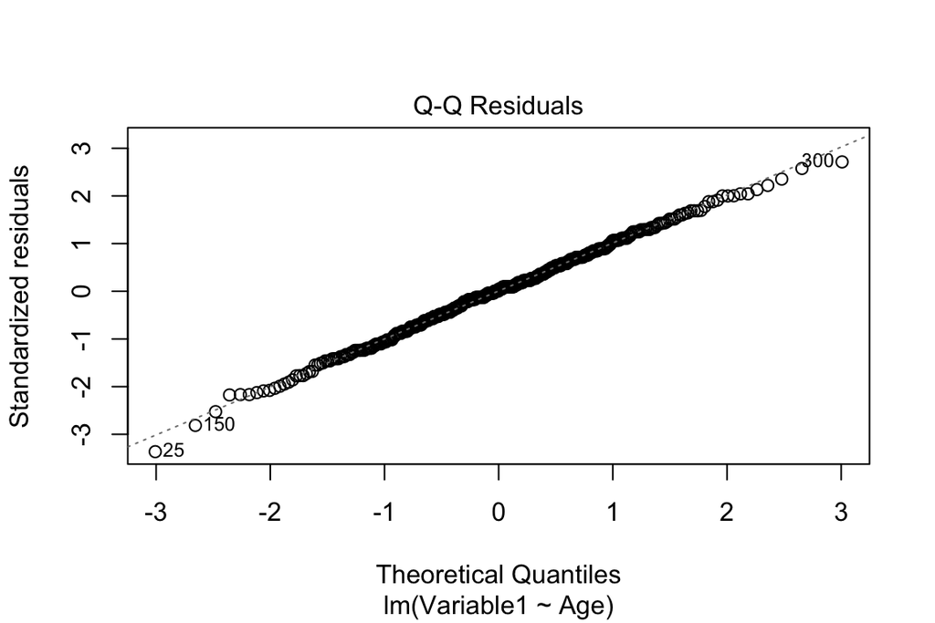

```r
plot(m, 2)
```

**You Try It**

Run a linear regression model and check **Normality of Residuals** assumption. Is the assumption met?

## 6.4 Homogeneity of Variance

### 6.4.1 Homoscedasticity

Similar to Normality of Residuals, we also need our model to check Homoscedasticity.

**Code Template for checking Homoscedasticity**

`plot(model_name, 1)`

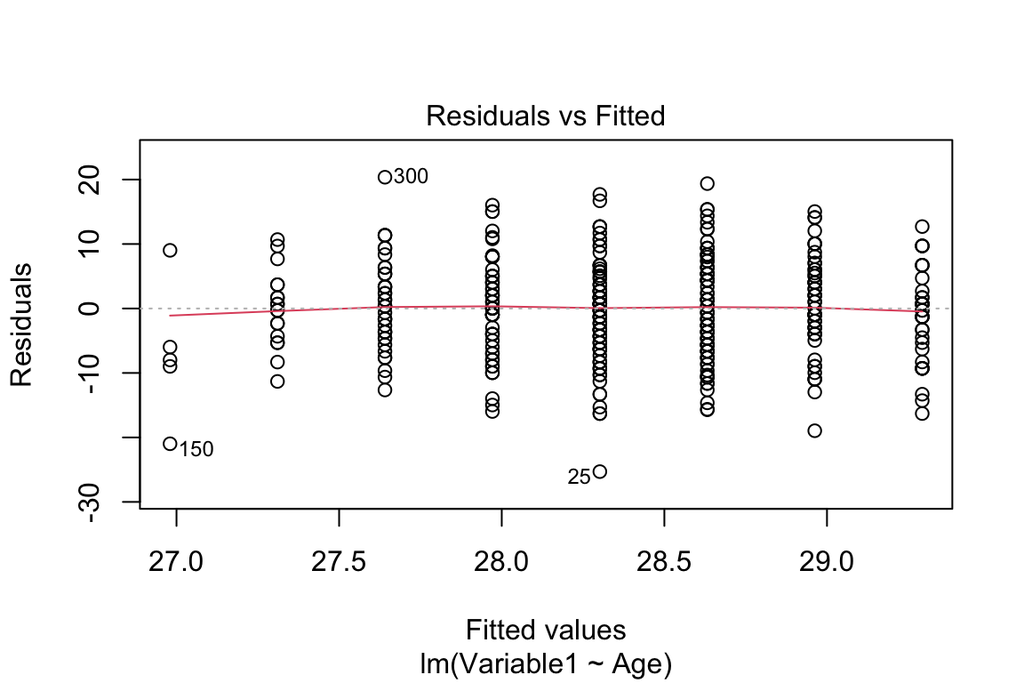

```r
plot(m, 1)
```

**You Try It**

Check **Homoscedasticity** assumption of your model. Is the assumption met?

### 6.4.2 Levene’s Test for ANOVAs

**Code Template for Levene’s Test**

`leveneTest(dv_name ~ iv_name, data = dataset_name)`

```r
leveneTest(Variable1 ~ as.factor(Sex), data = d)
```

```
## Levene's Test for Homogeneity of Variance (center = median)
##        Df F value Pr(>F)
## group   1       0   0.95
##       378
```

# 7 Dealing with Normality and Outliers

Common methods to deal with extreme values are:

- Removal of extreme values
- Winsorisation
- Transformation

**Tips**

Always inspect your plots again after transformation to check if the transformation has improved/addressed normality/outliers.

## 7.1 Checking distributions and outliers

Let’s use a very useful function `testDistribution()` combined with `plot()` from the `JWileymisc` package to check the distribution of a variable.

There are two parts to this graph that you may find helpful.

- The distribution of the raw data/variable is represented as a solid black line. A dashed blue line shows what a normal distribution would look like. If these two lines are close, that indicates the variable is approximately normally distributed.
- Outliers (if any) are identified in black while the rest of data points are light grey. We use `extremevalues = "theoretical"` argument to identify outliers. We then use `ev.perc` argument to specify the percentage of the theoretical distribution in each tail we consider extreme. For example `ev.perc = .005` means that we consider any score that is in the bottom 0.5% or top 0.5% of a normal distribution to be an “extreme” value. We can also use the top and bottom 0.1% (`ev.perc = .001`).

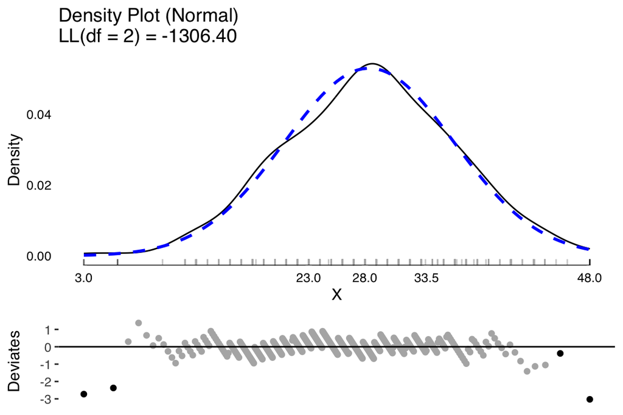

```r
plot(testDistribution(d$Variable1,
                      extremevalues = "theoretical", ev.perc = .005))
```

## 7.2 Removal of outliers

### 7.2.1 Subsetting by IDs

You can remove extreme values/participants by subsetting data by rows (we learnt this in week 3 workshop). As a refresher, when we subset data by rows, we specify our argument(s) in the `i` section of `DT[...]`. If our dataset has a ID variable (most dataset does), we can remove them using the participant ID. For example, assuming ID 10 is an outlier, we can remove them using `!=` which means `not equal`.

```r
d1 <- d[RandomID != 10]
```

### 7.2.2 Subsetting using z-scores

Finally, if we assume a variable follows a normal distribution, we may use z scores to identify extreme values or outliers using $z \pm 3.29$.

We will need to first create z-score for that variable using the `scale()` function.

```r
d[, ScaledVariable1 := scale(Variable1)]
```

Check the data using `table()` function. You can see that there is one extreme value based on z score.

```r
table(d$ScaledVariable1 > 3.29)
```

```
##
## FALSE
##   380
```

```r
table(d$ScaledVariable1 < -3.29)
```

```
##
## FALSE  TRUE
##   379     1
```

We can remove it using the code below:

```r
d <- d[ScaledVariable1 <3.29 & ScaledVariable1 > -3.29]
```

## 7.3 Winsorising

Instead of simply removing the data, we can winsorise them. That means we replace the extreme values with a certain percentile value from each end. We can winsorse our variables using the `winsor()` function. Use the `trim` argument to specify how much you would like to winsorise top & bottom (e.g, 0.5% or 1%).

```r
d[, Winsored_Variable1 := winsor(Variable1, trim = .005)]
d[, Winsored_Variable1 := winsor(Variable1, trim = .01)]
```

## 7.4 Transformation

There are two common transformations:

- Log
- Square root

We can perform these transformations using `log()` and `sqrt()`.

```r
d[, Log_Variable1 := log(Variable1)]
d[, Sqrt_Variable1 := sqrt(Variable1)]
```

**You Try It**

Create two new variables by transforming your variables using `log()` and `sqrt()`.

**Exercise**

Take a quick look at the histogram/distribution of your:

- Original variable
- Winsorised
- Log transformed
- Sqrt transformed

# 8 Exercises

Apply what we learn today to check assumptions and deal with any violations/outliers for your research report’s variables.